# report

## Executive Summary

Measuring receiver success in football is a nuanced challenge, especially in today’s game, where wide receivers, tight ends, and running backs all play key roles in the passing game. Completion percentage over expected is typically used to evaluate quarterback performance, but we applied this concept to pass catchers. To evaluate pass catcher value, we focused on how often a pass is completed when a player is targeted, compared to how likely that pass was to be completed.

Our model was inspired by estimating expected goals for soccer, which uses shot data to calculate expected goals and, further, goals above expected. Using play-by-play data from the NFLfastR data set, we estimated the probability of a pass being caught based on factors like down, distance, and air yards. We used data from the 2021-2023 seasons to predict receiving outcomes for the 2024 season. Plays missing key variables were excluded, as we couldn’t reliably fill in the gaps. We also limited our analysis to pass catchers with at least 50 targets per season to avoid skewed results. This benchmark was determined by our sources we found from [Sports Illustrated](https://www.si.com/nfl/2018/07/31/fantasy-football-2018-most-predictable-wide-receiver-stats) and [Next Generation Stats](https://nextgenstats.nfl.com/stats/receiving#yards), which suggest 65 and 42 as target benchmarks.

While our model offers meaningful insights, it has limitations. More advanced tracking data, such as receiver separation or proximity to the sideline, could improve our predictions and better capture pass catcher performance. These insights suggest that with smarter data and more intense models, teams can uncover more overlooked talent and rethink efficiency.

## Technical Report

### Overview

This project introduces a Completion Percentage Over Expected (CPOE) model tailored for pass catchers. Using the play-by-play data made available through the nflfastR package, we created a model that predicts at what rate a receiver catches a target over what is expected. While CPOE traditionally measures Completion Percentage Over Expected of a quarterback, we wanted to determine how this could be applied to pass catchers. This model was influenced by Lectures 2 and 3 in our sports analytics class tought by professor Sameer Deshpande, dealing with expected goals in soccer. This report will break down how we constructed our model and show application of the model regarding the 2021-2024 NFL seasons.

### Data Gathering

Before beginning model training, we first ensured that our data set was usable and relevant. The first step was to narrow down the range of data. We selected the 2021 through 2024 NFL seasons for training and testing purposes (we will explain this in detail later). This time frame was chosen because it reflects the relatively modern game play trends, increasing the likelihood that our model will generalize well to future seasons. We excluded the 2020 season, which was an outlier due to COVID. To source our data, we used the nflfastR package, which provides a wide range of play-by-play variables that are suitable for modeling and this data is supported with great documentation and resources.

```r
library(nflfastR)
set.seed(2024)
pbp_train = load_pbp(2021:2023)
pbp_2024 = load_pbp(2024)
```

### Data Preparation

To begin we filtered out all plays that were not passing plays during the regular season. We chose to focus exclusively on regular season data to avoid introducing variability from preseason or postseason contexts, which could act as a confounding predictor. Next, we removed plays that resulted in a sack, spike, kneel, throwaway, or aborted pass, these events prevent a pass catcher from having a legitimate opportunity to complete the target and would distort the model. We also excluded two-point conversion attempts to maintain consistency with standard offensive phases and avoid skewing the model with rare and atypical plays. After isolating the valid passing plays, we selected a subset of variables relevant to our modeling goals (discussed in the next section) and cleaned the data set accordingly. Specifically we dropped any rows with missing values in the following fields: completed_pass, air_yards, pass_location, down, ydstogo, yardline_100, and reciever_player_id. This ensured that each target in our data set had complete information for all predictors required to estimate completion probability.

```r
train_pass <-
  pbp_train %>%
  dplyr::filter(play_type=="pass", season_type=="REG") %>%
  dplyr::filter(
    !grepl("TWO-POINT CONVERSION ATTEMPT", desc),
    !grepl("sack", desc, ignore.case = TRUE),
    !grepl("spike", desc, ignore.case = TRUE),
    !grepl("kneel", desc, ignore.case = TRUE),
    !grepl("throwaway", desc, ignore.case = TRUE),
    !grepl("aborted", desc, ignore.case = TRUE)
  ) %>%
  dplyr::select(
    game_id, play_id, complete_pass, air_yards, shotgun, no_huddle, qb_hit, posteam_type, pass_location,
    yardline_100, down, ydstogo, posteam, defteam, passer_player_id, desc, receiver_player_id, receiver_player_name, season
  ) %>%
  dplyr::filter(
    !is.na(complete_pass),
    !is.na(air_yards),
    !is.na(pass_location),
    !is.na(down),
    !is.na(ydstogo),
    !is.na(yardline_100),
    !is.na(receiver_player_id)
  ) %>%
  dplyr::mutate(
    shotgun = ifelse(is.na(shotgun), 0L, shotgun),
    no_huddle = ifelse(is.na(no_huddle), 0L, no_huddle),
    qb_hit = ifelse(is.na(qb_hit), 0L, qb_hit),
    posteam_type = factor(posteam_type),
    pass_location = factor(pass_location),
    down = factor(down),
  )
```

```r
test_pass <-
  pbp_2024 %>%
  dplyr::filter(play_type == "pass", season_type== "REG") %>%
  dplyr::filter(
    !grepl("TWO-POINT CONVERSION ATTEMPT", desc),
    !grepl("sack", desc, ignore.case = TRUE),
    !grepl("spike", desc, ignore.case = TRUE),
    !grepl("kneel", desc, ignore.case = TRUE),
    !grepl("throwaway", desc, ignore.case = TRUE),
    !grepl("aborted", desc, ignore.case = TRUE)
  ) %>%
  dplyr::select(
    game_id, play_id ,complete_pass, air_yards, shotgun, no_huddle, qb_hit, posteam_type, pass_location,
    yardline_100, down, ydstogo, posteam, defteam, passer_player_id, desc, receiver_player_id, receiver_player_name, season
  ) %>%
  dplyr::filter(
    !is.na(complete_pass),
    !is.na(air_yards),
    !is.na(pass_location),
    !is.na(down),
    !is.na(ydstogo),
    !is.na(yardline_100),
    !is.na(receiver_player_id)
  ) %>%
  dplyr::mutate(
    shotgun = ifelse(is.na(shotgun), 0L, shotgun),
    no_huddle = ifelse(is.na(no_huddle), 0L, no_huddle),
    qb_hit = ifelse(is.na(qb_hit), 0L, qb_hit),
    posteam_type = factor(posteam_type, levels = levels(train_pass$posteam_type)),
    pass_location = factor(pass_location, levels = levels(train_pass$pass_location)),
    down = factor(down, levels = levels(train_pass$down)),
  )
```

### Feature Selection

Most modern CPOE models rely on a combination of play-by-play data and advanced player tracking data. For this project, we chose to work exclusively with play-by-play data due to the difficulty of acquiring and processing tracking data. While this choice limits the amount of variables that we can work with, we selected variables as best as we could to capture situation context.

The variables used in our model include:

- Air yards: Measures the depth of the throw, a key indicator for difficulty.
- Formation: Whether the play began in shotgun or under-center.
- No-huddle: Indicates the tempo and urgency of the play.
- QB hits: Explains pressure or interference.
- Pass location: Left, right, or center.
- Yardline: The starting field position, which influences play calling.
- Down and Distance: Captures game situation and urgency.

```r
comp_glm <- glm(
  complete_pass ~ air_yards + shotgun + no_huddle + qb_hit + pass_location+ yardline_100 + down + ydstogo,
  data= train_pass,
  family=binomial()
)
```

```
##                                Variable Estimate Std_Error z_value Significant
## (Intercept)                 (Intercept)    1.043     0.043   24.11         Yes
## air_yards                     air_yards   -0.063     0.001  -61.89         Yes
## shotgun                         shotgun   -0.195     0.029   -6.70         Yes
## no_huddle                     no_huddle    0.089     0.031    2.88         Yes
## qb_hit                           qb_hit   -0.845     0.033  -25.31         Yes
## pass_locationmiddle pass_locationmiddle    0.117     0.027    4.40         Yes
## pass_locationright   pass_locationright   -0.029     0.022   -1.32          No
## yardline_100               yardline_100    0.007     0.000   17.08         Yes
## down2                             down2   -0.032     0.024   -1.33          No
## down3                             down3   -0.165     0.027   -6.07         Yes
## down4                             down4   -0.329     0.063   -5.23         Yes
## ydstogo                         ydstogo    0.014     0.003    5.19         Yes
```

### Model Training

We used the [ranger](https://imbs-hl.github.io/ranger/index.html) package to implement a random forest classifier for predicting completion probability. While we do not detail every modeling parameter in this report, our choices were guided by two considerations.

1. Function Approximation: Random forests are considered universal approximaters, meaning they can model highly nonlinear relationships. This means that for every function that exists there is a regression tree that can approximate it. This is essential for capturing complex football plays.
2. Interaction Modeling: Football is very interactive. For example, a 10- yard pass to the left side of the field differs dramatically from a 50-yard pass to the same area. Random forests can capture this complex interaction data and Interactions are also important for modeling CPOE.

To avoid sampling bias, we split the data by season: training on 2021-2023 and testing on 2024. This ensures that our model is evaluated on unseen data and simulates real-world conditions. This was also important to ensure no in-sampling testing occurred.

```r
y_train = train_pass$complete_pass
y_test = test_pass$complete_pass

train_data = train_pass %>%
select(complete_pass, air_yards, shotgun, no_huddle, qb_hit, pass_location, yardline_100, down, ydstogo)

test_data = test_pass %>%
select(complete_pass, air_yards, shotgun, no_huddle, qb_hit, pass_location, yardline_100, down, ydstogo)

train_data <- train_data %>%
mutate(complete_pass = factor(complete_pass, levels = c(0,1)))

test_data <- test_data %>%
mutate(complete_pass = factor(complete_pass, levels = c(0,1)))
```

```r
library(ranger)
fit = ranger(
    formula = complete_pass~ .,
    data = train_data,
    probability = TRUE)

#Predict on our training and test data
train_pass$train_preds =
  predict(object = fit, data = train_pass)$predictions[,2]

test_pass$test_preds =
  predict(object = fit, data = test_pass)$predictions[,2]

train_data$train_preds = predict(fit, data = train_data)$predictions[,2]
test_data$test_preds  = predict(fit, data = test_data)$predictions[,2]
```

In order to evaluate our model we’ll use log-loss.

```r
logloss = function(y, phat){
  phat = pmin(pmax(phat, 1e-12), 1 - 1e-12)
  return(-mean(y * log(phat) + (1-y) * log(1 - phat)))}

train_logloss = logloss(y_train, train_pass$train_preds)
test_logloss  = logloss(y_test,  test_pass$test_preds)
```

```
##   Model LogLoss
## 1 Train 0.51633
## 2  Test 0.55564
```

### Results

With the model trained and validated, we applied it to all targets from 2021-2024 regular season data. For each target, the model outputs a predicted probability of completion. We then aggregated these predictions by pass catcher to compare expected completion rates against actual performance.

To ensure reliability of our estimates, we limited our analysis to pass catchers with at least 50 targets. This threshold was chosen by looking at industry sources including [fantasypoints.com](https://www.fantasypoints.com/nfl/articles/2023/fantasy-points-data-most-important-wr-stats#/), [4for4.com](https://www.4for4.com/2024/preseason/most-predictable-wide-receiver-stats), [Sports Illustrated](https://www.si.com/nfl/2018/07/31/fantasy-football-2018-most-predictable-wide-receiver-stats), and [Next Gen Stats](https://nextgenstats.nfl.com/stats/receiving#yards) to determine a range of targets that would be acceptable.

The relationship between predicted and actual success rates was moderately strong, with an r^2 value of .60 in the 2024 season. This suggests that our model captures a good proportion of the variance in catch passer performance.

```r
summary_24 = test_pass %>%
  group_by(receiver_player_name, season) %>%
  summarise(
    avg_predicted_suc = mean(test_preds),
    actual_success = mean(as.numeric(as.character(complete_pass))),
    n_targets = n()) %>%
  arrange(desc(actual_success)) %>%
  filter(n_targets > 50) %>%
  mutate(wrcpoe = actual_success - avg_predicted_suc) %>%
  rename(Name = receiver_player_name)
summary21_23 = train_pass %>%
  group_by(receiver_player_name, season) %>%
  summarise(
    avg_predicted_suc = mean(train_preds),
    actual_success = mean(as.numeric(as.character(complete_pass))),
    n_targets = n()) %>%
  arrange(desc(actual_success)) %>%
  filter(n_targets > 50) %>%
  mutate(wrcpoe = actual_success - avg_predicted_suc) %>%
  rename(Name = receiver_player_name)
summary = rbind(summary21_23, summary_24)
```

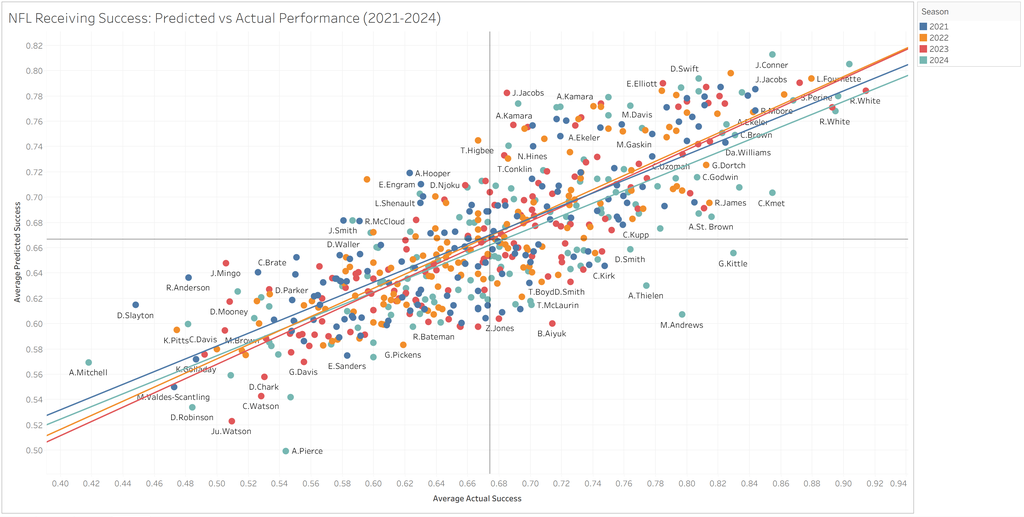

2021 r^2 = 0.612367, 2022 r^2 = 0.684678, 2023 r^2 = 0.666335, 2024 r^2 = 0.600968

For a clearer a picture of the top and bottom players when it comes to CPOE we sorted the top and bottom performers into a graph.

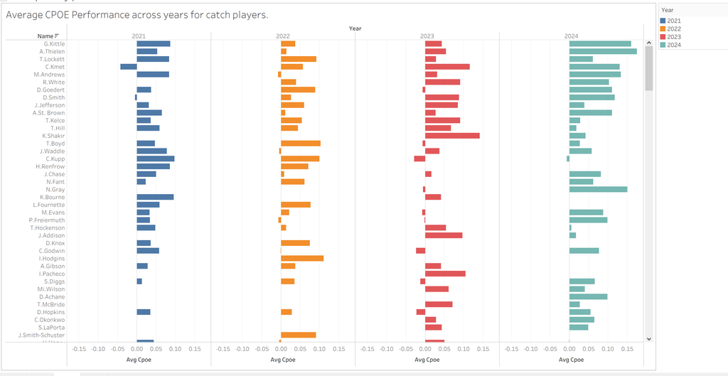

Top Performers

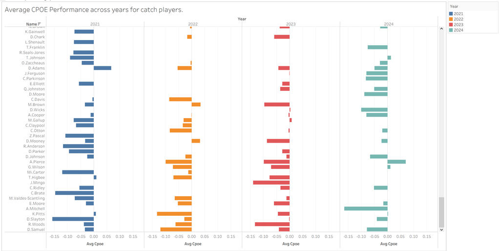

Bottom Performers

Another question is how pass catcher volume has an effect on efficiency? We determined that volume has little to no correlation with efficiency as seen below.

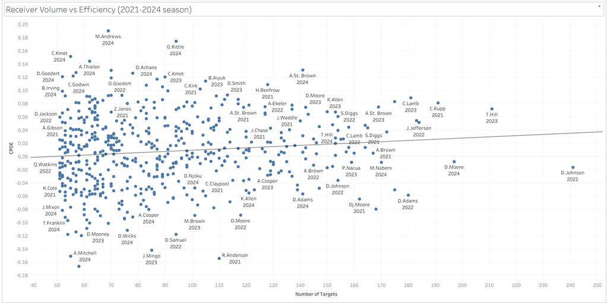

An important note for all of our results is that due to the lack of tracking data, our model doesn’t do a great job of knowing good throws from bad ones and similarly good routes from bad ones. Since we only have play-by-play data our model is good at predicting the likelihood of a catch based on situations rather then separation or accuracy. This results in the majority of our predictions being based off the types of opportunities each player gets rather then skill. Take for example De’von Achane who is schemed up at a lot of check down routes and screen passes, these passes are inherently easier to catch and are not due to Achane or his QB doing anything particularly impressive.

### Examples

As a compliment to our predictive model, we chose a few players to show the predictions in real time throughout the seasons we chose. We chose the following players: Cole Kmet, De’Von Achane, DeAndre Hopkins, and Kenny Golladay. We searched for specific games and plays that highlight great catches and bad catches. We then calculated there probability of that play happening compared with our model. Finally we provided a video for each player to show the plays in action.

```r
pbp = rbind(pbp_train, pbp_2024)

pbp$predicted = predict(object = fit, data = pbp)$predictions[,2]
```

```r
pbp_lookup = pbp %>%
  select(play_id, id, game_id, receiver_player_name, air_yards, down, half_seconds_remaining, predicted) %>%
  filter(!is.na(receiver_player_name))
```

```r
lookup = function(gid, pid) {
  value = pbp_lookup %>%
    filter(
      game_id == gid,
      play_id == pid
    )
  return(value$predicted)
}
```

#### Cole Kmet

Link: https://www.youtube.com/watch?v=KvfqOeWtNyM

[video not shown]

Looking through his 2024 highlights, catches like (0:47) and (0:58) show the baseline of what tight ends do in the NFL. They are expected to make solid and strong catches in the middle of the field. What really justifies his 2024 season’s placement in our data are catches like (1:03) that put his actual success above his expected success with unlikely receptions.

```r
table = data.frame(
  timestamp = c(":47", ":58", "1:03"),
  gid = c("2024_03_CHI_IND", "2024_03_CHI_IND", "2024_03_CHI_IND"),
  pid = c(3475, 3694, 4168)
)

table$catch_probability <- as.numeric(mapply(lookup, table$gid, table$pid, SIMPLIFY = TRUE))

table
```

```
##   timestamp             gid  pid catch_probability
## 1       :47 2024_03_CHI_IND 3475         0.7962252
## 2       :58 2024_03_CHI_IND 3694         0.7718014
## 3      1:03 2024_03_CHI_IND 4168         0.6070081
```

#### De’von Achane

One of the highest predicted successes is De’von Achane (2024) and it is accompanied by an even higher Actual Success rating. The top right quadrant of the graph in ‘NFL Receiving Success: Predicted vs. Actual Performance (2021-2024)’ is primarily running backs because of check down passes. Respectively, the starting predicted success will be much higher to begin with and the players that are highest up on the Actual Success will be the most reliable when it comes to catching those dump-off passes.

Link: https://www.youtube.com/watch?v=YaBOqrWhZfM

[video not shown]

We see at time marks: (0:44), (1:14), and (6:05) that these check downs are frequent and easy, supporting the claim that Achane is a very reliable dump-off target and gets to the open spots on the field to help out his QB.

```r
table = data.frame(
  timestamp = c(":44", "1:14", "6:05"),
  gid = c("2024_02_BUF_MIA","2024_02_BUF_MIA", "2024_13_MIA_GB"),
  pid = c(669, 2396, 2905)
)

table$catch_probability <- as.numeric(mapply(lookup, table$gid, table$pid, SIMPLIFY = TRUE))

table
```

```
##   timestamp             gid  pid catch_probability
## 1       :44 2024_02_BUF_MIA  669         0.7765499
## 2      1:14 2024_02_BUF_MIA 2396         0.8302349
## 3      6:05  2024_13_MIA_GB 2905         0.8163801
```

#### DeAndre Hopkins

Link: https://www.youtube.com/watch?v=bRhdN3z2OUI

[video not shown]

```r
table = data.frame(
  timestamp = c(":04", ":32", "2:21", "4:32", "6:01", "8:38"),
  gid = c("2023_03_TEN_CLE","2023_04_CIN_TEN", "2023_08_ATL_TEN", "2023_13_IND_TEN", "2023_14_TEN_MIA", "2023_18_JAX_TEN"),
  pid = c(2005, 1504, 1583, 1445, 2045, 1679)
)

table$catch_probability <- as.numeric(mapply(lookup, table$gid, table$pid, SIMPLIFY = TRUE))

table
```

```
##   timestamp             gid  pid catch_probability
## 1       :04 2023_03_TEN_CLE 2005         0.4280807
## 2       :32 2023_04_CIN_TEN 1504         0.4011822
## 3      2:21 2023_08_ATL_TEN 1583         0.7151600
## 4      4:32 2023_13_IND_TEN 1445         0.5699244
## 5      6:01 2023_14_TEN_MIA 2045         0.4115675
## 6      8:38 2023_18_JAX_TEN 1679         0.6100048
```

#### Kenny Golladay

On the lower end of our ’NFL Receiving Success: Predicted vs. Actual Performance (2021-2024) graph we have Kenny Golladay’s 2021 season with lower Actual Success than Predicted. This can be explained as simply not catching the ball when you are in an easy situation to do so.

Link: https://www.youtube.com/watch?v=Qs4IBYUAoiY

[video not shown]

Here we see at the time marker (0:02) the ball goes directly through his hands without much coverage at the point of reception.

```r
table = data.frame(
  timestamp = c(":02"),
  gid = c("2021_02_NYG_WAS"),
  pid = c(2730)
)

table$catch_probability <- as.numeric(mapply(lookup, table$gid, table$pid, SIMPLIFY = TRUE))

table
```

```
##   timestamp             gid  pid catch_probability
## 1       :02 2021_02_NYG_WAS 2730         0.6793609
```

## References

Barfield, Graham. “Fantasy Points Data: Most Important WR STATS.” Fantasy Points, July 29, 2023. https://www.fantasypoints.com/nfl/articles/2023/fantasy-points-data-most-important-wr-stats#/.

Deshpande, Sameer. “Lecture 2: Expected Goals.” Lecture 2: Expected Goals – STAT479, September 2025. https://skdeshpande91.github.io/stat479_fall2025/lectures/lecture02.html.

Deshpande, Sameer. “Lecture 3: Estimating XG.” Lecture 3: Estimating XG – STAT479, September 2025. https://skdeshpande91.github.io/stat479_fall2025/lectures/lecture03.html.

Hernandez, TJ. “The Most Predictable Wide Receiver Stats.” SI, July 31, 2018. https://www.si.com/nfl/2018/07/31/fantasy-football-2018-most-predictable-wide-receiver-stats.

Hoopes, Stephen. “The Most Predictable Wide Receiver Stats.” 4for4 Fantasy Football, July 8, 2024. https://www.4for4.com/2024/preseason/most-predictable-wide-receiver-stats.

“Ngs: NFL next Gen Stats.” Next Gen Stats. Accessed October 7, 2025. https://nextgenstats.nfl.com/stats/receiving#yards.

“An R Package to Quickly Obtain Clean and Tidy NFL Play by Play Data.” Dev status. Accessed October 6, 2025. https://www.nflfastr.com/index.html.